# Bay Wheels dataset (January, 2020) - Communicating Data Findings

## by Daniel Perez

## Preliminary Wrangling

> Hello!  
> This exploratory effort will be made using a file containing numerous bike trips, which were made using Bay Wheels, a San Francisco bike share regional system owned by Lyft and operated by Motivate. The main purpose will be to analyze and uncover trends within the variables, enabling us to draw consistent conclusions and insights about the data, and to furthermore ellaborate a clean and comprehensible visual presentation concerning these findings.

### Importing Libraries

```python
# import all packages and set plots to be embedded inline
import numpy as np
import pandas as pd
import matplotlib.pyplot as plt
import seaborn as sb

%matplotlib inline
```

### Loading the Dataset

```python
# Dataset already included in the notebook, extracted from Lyft's website:
bike_data = pd.read_csv('bay_wheels_data.csv')
bike_data.head()
```

|  | duration_sec | start_time | end_time | start_station_id | start_station_name | start_station_latitude | start_station_longitude | end_station_id | end_station_name | end_station_latitude | end_station_longitude | bike_id | user_type | bike_share_for_all_trip | rental_access_method |
| --- | --- | --- | --- | --- | --- | --- | --- | --- | --- | --- | --- | --- | --- | --- | --- |
| 0 | 83118 | 2020-01-31 15:23:47.7330 | 2020-02-01 14:29:06.2630 | 400.0 | Buchanan St at North Point St | 37.804272 | -122.433537 | 400.0 | Buchanan St at North Point St | 37.804272 | -122.433537 | 13052 | Customer | No | NaN |
| 1 | 68239 | 2020-01-31 15:40:31.6160 | 2020-02-01 10:37:51.0000 | 99.0 | Folsom St at 15th St | 37.767037 | -122.415443 | 99.0 | Folsom St at 15th St | 37.767037 | -122.415443 | 12235 | Subscriber | Yes | NaN |
| 2 | 55407 | 2020-01-31 17:48:16.6350 | 2020-02-01 09:11:44.3170 | 197.0 | El Embarcadero at Grand Ave | 37.808848 | -122.249680 | 197.0 | El Embarcadero at Grand Ave | 37.808848 | -122.249680 | 12822 | Customer | No | NaN |
| 3 | 54929 | 2020-01-31 17:53:03.4130 | 2020-02-01 09:08:32.6340 | 197.0 | El Embarcadero at Grand Ave | 37.808848 | -122.249680 | 197.0 | El Embarcadero at Grand Ave | 37.808848 | -122.249680 | 11705 | Customer | No | NaN |
| 4 | 55700 | 2020-01-31 17:12:33.4600 | 2020-02-01 08:40:53.6460 | 12.0 | Pier 1/2 at The Embarcadero | 37.796389 | -122.394586 | 371.0 | Lombard St at Columbus Ave | 37.802746 | -122.413579 | 3673 | Customer | No | NaN |

```python
bike_data.info()
```

```
<class 'pandas.core.frame.DataFrame'>
RangeIndex: 295854 entries, 0 to 295853
Data columns (total 15 columns):
duration_sec               295854 non-null int64
start_time                 295854 non-null object
end_time                   295854 non-null object
start_station_id           146286 non-null float64
start_station_name         146866 non-null object
start_station_latitude     295854 non-null float64
start_station_longitude    295854 non-null float64
end_station_id             145934 non-null float64
end_station_name           146511 non-null object
end_station_latitude       295854 non-null float64
end_station_longitude      295854 non-null float64
bike_id                    295854 non-null int64
user_type                  295854 non-null object
bike_share_for_all_trip    110108 non-null object
rental_access_method       185746 non-null object
dtypes: float64(6), int64(2), object(7)
memory usage: 33.9+ MB
```

### As we can see, the dataset is composed by 295854 rows and 15 columns, concerning bike trips travel time info, its start and end station locations, bike id and user type, rental mode and even some Bike Share For All data, which is a campaign launched in early 2016 by San Francisco Bicycle Coalition, aimed at an equitable bike share system.

### In this exploration, we'll address the 'where', the 'who', the 'when' and the 'how'. For that reason, these will be the variables of interest:

#### - duration_sec (trip duration)

#### - start_time

#### - start_station_name

#### - end_station_name

#### - user_type

#### - bike_share_for_all_trip

#### - rental_access_method

## Univariate Exploration

### First things first, let's take a look at our variables of interest individually, to check their overall characteristics:

### Duration_min

### Starting by the trip duration variable, let's pass it through a descriptive function:

```python
bike_data.duration_sec.describe()
```

```
count    295854.000000
mean        780.473193
std        2037.786317
min          60.000000
25%         369.000000
50%         588.000000
75%         912.000000
max      811077.000000
Name: duration_sec, dtype: float64
```

### Before any valid observation, it is important to address that the maximum value is very distant from the third quartile value, possibly denouncing unrealistic occurrences. Let's take a closer look, and to allow for a more summarized result, let's transform the values from seconds to minutes:

```python
bike_data.duration_sec = (bike_data.duration_sec / 60).astype(int)
```

### Let's produce a histogram, ranging from 0 to 120 minutes, and count the total of occurrences:

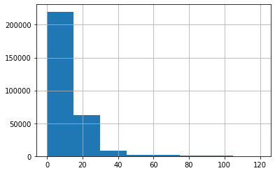

```python
bike_data.duration_sec.hist(bins = [0, 15, 30, 45, 60, 75, 90, 105, 120]);
```

```python
bike_data.query('duration_sec <= 120').duration_sec.count()
```

```
295159
```

### The histogram shows us the distribution, aligned with a count of 295159 values from 0 to 120 minutes, which indicates that almost all the values are located between 1 (the minimum value) to 120 minutes duration

```python
duration_120 = bike_data.query('duration_sec > 120').duration_sec.count()
duration_120/bike_data.shape[0]
```

```
0.0023491316662948617
```

### In fact the vast majority of values is located between the 2-hour range, and exceeding values represent around 0,2 % of all elements, as displayed above. For that reason, let's remove the values that surpass the 120-minutes mark, in order to also remove any outliers that could mislead our conclusions:

```python
bike_data = bike_data[bike_data.duration_sec <= 120]
```

```python
bike_data.duration_sec.describe()
```

```
count    295159.000000
mean         11.759885
std          10.226313
min           1.000000
25%           6.000000
50%           9.000000
75%          15.000000
max         120.000000
Name: duration_sec, dtype: float64
```

### With this we eliminated the odd ones and filtered the values allowing for a more realistic analysis. Let's produce another histogram with cleaner values:

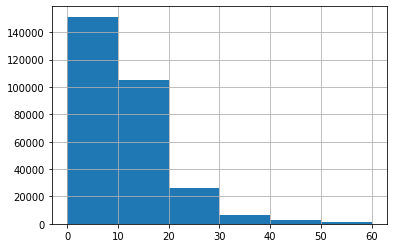

```python
bike_data.duration_sec.hist(bins = [0, 10, 20 ,30, 40, 50, 60]);
```

### Indeed the distribution is centralized between 0 to 20 minutes, with a steep slope after it

```python
# renaming the column to 'duration_min':
bike_data.rename(columns={'duration_sec':'duration_min'}, inplace=True)
```

### Start_time

### To better understand and work with this feature, let's split the datetime values into two separate columns (date and hour of the day):

```python
# converting the start_time column to datetime, and splitting into two columns

bike_data['day'] = bike_data['start_time'].str[8:10]
bike_data['hour_of_day'] = bike_data['start_time'].str[11:13]
bike_data['day'] = bike_data['day'].astype(int)
bike_data['hour_of_day'] = bike_data['hour_of_day'].astype(int)

# removing the 'start_time' column:

bike_data.drop(columns='start_time', inplace=True)

# rearranging the column order:

bike_data = bike_data[['duration_min',
                       'day',
                       'hour_of_day',
                       'end_time',
                       'start_station_id',
                       'start_station_name',
                       'start_station_latitude',
                       'start_station_longitude',
                       'end_station_id',
                       'end_station_name',
                       'end_station_latitude',
                       'end_station_longitude',
                       'bike_id',
                       'user_type',
                       'bike_share_for_all_trip',
                       'rental_access_method']]
```

```python
bike_data.head()
```

|  | duration_min | day | hour_of_day | end_time | start_station_id | start_station_name | start_station_latitude | start_station_longitude | end_station_id | end_station_name | end_station_latitude | end_station_longitude | bike_id | user_type | bike_share_for_all_trip | rental_access_method |
| --- | --- | --- | --- | --- | --- | --- | --- | --- | --- | --- | --- | --- | --- | --- | --- | --- |
| 7 | 67 | 31 | 23 | 2020-02-01 00:39:22.0210 | 450.0 | Funston Ave at Irving St | 37.763934 | -122.470651 | 450.0 | Funston Ave at Irving St | 37.763934 | -122.470651 | 1589 | Customer | No | NaN |
| 8 | 67 | 31 | 23 | 2020-02-01 00:38:40.8570 | 450.0 | Funston Ave at Irving St | 37.763934 | -122.470651 | 450.0 | Funston Ave at Irving St | 37.763934 | -122.470651 | 12884 | Customer | No | NaN |
| 9 | 33 | 31 | 23 | 2020-02-01 00:22:09.7540 | 238.0 | MLK Jr Way at University Ave | 37.871719 | -122.273068 | 198.0 | Snow Park | 37.807813 | -122.264496 | 10464 | Customer | No | NaN |
| 10 | 32 | 31 | 23 | 2020-02-01 00:21:53.5730 | 238.0 | MLK Jr Way at University Ave | 37.871719 | -122.273068 | 198.0 | Snow Park | 37.807813 | -122.264496 | 12120 | Customer | No | NaN |
| 11 | 26 | 31 | 23 | 2020-02-01 00:16:02.4310 | 174.0 | Shattuck Ave at 51st St | 37.836801 | -122.264004 | 259.0 | Addison St at Fourth St | 37.866249 | -122.299371 | 838 | Subscriber | Yes | NaN |

### Good! now, let's explore these newly created columns, starting from the 'day' column:

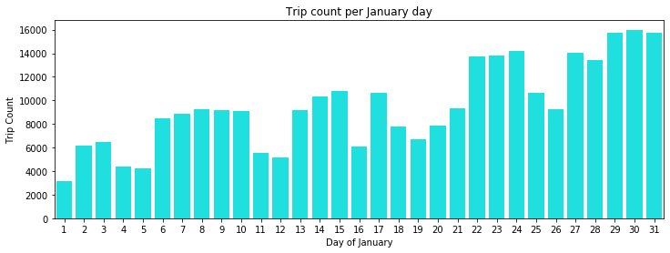

```python
plt.figure(figsize=(12, 4))
sb.countplot(data = bike_data, x = 'day', color = 'cyan')
plt.title('Trip count per January day')
plt.xlabel('Day of January')
plt.ylabel('Trip Count');
```

```python
bike_data.day.value_counts().describe()
```

```
count       31.000000
mean      9521.258065
std       3635.326743
min       3115.000000
25%       6567.500000
50%       9193.000000
75%      12097.000000
max      15992.000000
Name: day, dtype: float64
```

### Apparently there's a slight left skew, indicating that the number of trips rise to the end of the month. the mean of trips per day is 9521, and the median is 9193. Also, as displayed by the plot, there's a visible usage decrease on weekends (4-5, 11-12, 18-19 and 25-26)

### Now, to the 'hour_of_day' column:

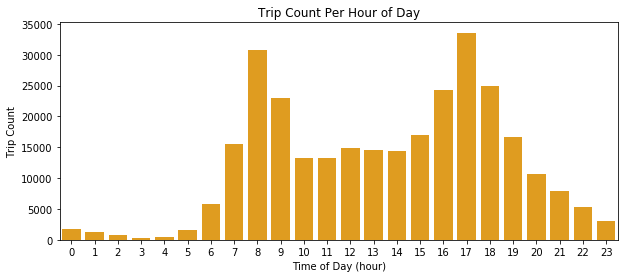

```python
plt.figure(figsize=[10,4])
sb.countplot(data = bike_data, x = 'hour_of_day', color = 'orange')
plt.title('Trip Count Per Hour of Day')
plt.xlabel('Time of Day (hour)')
plt.ylabel('Trip Count');
```

### through this bar plot, we can observe a bimodal distribution, with peaks happening in the middle of the morning and also in the late afternoon, closer to beginning and end of work hours

### Start_station_name

```python
bike_data.start_station_name.describe()
```

```
count                   146350
unique                     430
top       Market St at 10th St
freq                      2743
Name: start_station_name, dtype: object
```

### We have 430 unique station names, with the most frequent station having a frequency of 2743 occurrences

```python
bike_data.start_station_name.isna().sum()/bike_data.shape[0]
```

```
0.5041655514485412
```

### From all the rows, approximately half of 'start_station_name' values are missing

### End_station_name

```python
bike_data.end_station_name.describe()
```

```
count                                             146009
unique                                               429
top       San Francisco Caltrain (Townsend St at 4th St)
freq                                                5016
Name: end_station_name, dtype: object
```

### We have 429 unique station names, with the most frequent station having a frequency of 5016 occurrences

```python
bike_data.end_station_name.isna().sum()/bike_data.shape[0]
```

```
0.5053208609596861
```

### From all the rows, approximately half of 'end_station_name' values are missing

### User_type

### Let's analyze the first dicotomical column:

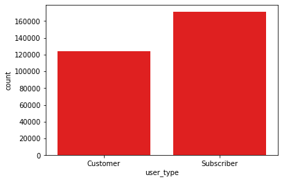

```python
sb.countplot(data = bike_data, x = 'user_type', color = 'r');
```

```python
print('% of subscribers: {}'.format(bike_data.query('user_type == "Subscriber"').user_type.count()/bike_data.shape[0]))
print('% of customers: {}'.format(bike_data.query('user_type == "Customer"').user_type.count()/bike_data.shape[0]))
```

```
% of subscribers: 0.5789083172120789
% of customers: 0.4210916827879211
```

### As we can see, there's a bigger frequency of subscribers compared to casual users

```python
bike_data.user_type.isna().sum()
```

```
0
```

### No occurrence of missing values in this column!

### Bike_share_for_all

```python
bike_data.bike_share_for_all_trip.unique()
```

```
array(['No', 'Yes', nan], dtype=object)
```

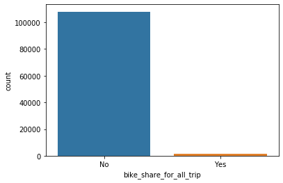

```python
sb.countplot(data = bike_data, x= 'bike_share_for_all_trip');
```

### Through this bar chart, we can see a big differente between both values, as well as a lot of missing values. Let's take a look at their counts:

```python
bike_data.bike_share_for_all_trip.value_counts()
```

```
No     107939
Yes      1689
Name: bike_share_for_all_trip, dtype: int64
```

```python
bike_data.bike_share_for_all_trip.isna().sum()
```

```
185531
```

### The 'yes' cases represent around 1% of valid values, and in parallel the majority of values are missing.

### Rental_access_method

```python
bike_data.rental_access_method.unique()
```

```
array([nan, 'app', 'clipper'], dtype=object)
```

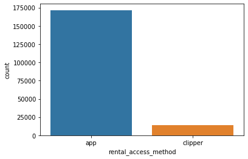

```python
sb.countplot(data = bike_data, x= 'rental_access_method');
```

### According to this bar plot, the vast majority of values are represented by the app rental method. Let's zoom in on their actual values:

```python
bike_data.rental_access_method.value_counts()
```

```
app        171545
clipper     13986
Name: rental_access_method, dtype: int64
```

```python
print('% of Clipper users: {}'.format(bike_data.rental_access_method.value_counts()[1]/
                                      bike_data.rental_access_method.value_counts()[0]))
print('% of App users: {}'.format(bike_data.rental_access_method.value_counts()[0]/
                                  bike_data.rental_access_method.value_counts().sum()))
```

```
% of Clipper users: 0.08152962779445627
% of App users: 0.92461637138807
```

### Indeed the clipper rental method represents 8% of trips, compared to 92% app uses

### To finalize our univariate exploration phase, let's drop the columns that we do not need:

```python
bike_data.drop(columns=['end_time',
                        'start_station_id',
                        'start_station_latitude',
                        'start_station_longitude',
                        'end_station_id',
                        'end_station_latitude',
                        'end_station_longitude',
                        'bike_id'], inplace=True)
```

```python
bike_data.columns
```

```
Index(['duration_min', 'day', 'hour_of_day', 'start_station_name',
       'end_station_name', 'user_type', 'bike_share_for_all_trip',
       'rental_access_method'],
      dtype='object')
```

### All set!

## Bivariate Exploration

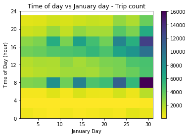

```python
plt.hist2d(data = bike_data, x = 'day', y = 'hour_of_day', cmap = 'viridis_r')
plt.colorbar()
plt.title('Time of day vs January day - Trip count')
plt.xlabel('January Day')
plt.ylabel('Time of Day (hour)')
plt.yticks(np.arange(0,25,4));
```

### As we can see by this heatmap, the already observed consistency in the start time on the mid-morning (close to 8 am) and mid to late afternoon (close to 17 pm) endure during the whole month, accentuating during time. The latter can be related to the trip count increase towards the end of the month, represented by the ascending count pattern seen in the trip count by day plot on the univariate exploration.

### What about the members and non-members of the Bike Share For All program? Do the start time hours follow the same pattern from above based on this feature?

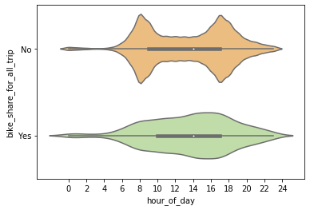

```python
x_bins = np.arange(0, 25, 2)
sb.violinplot(data = bike_data, y = 'bike_share_for_all_trip', x = 'hour_of_day', palette='Spectral')
plt.xticks(x_bins);
```

### As we can see from this violin plot, the members present a different behaviour concerning their bike use, showing a more homogeneous characteristic compared to the non-members bimodal pattern, peaking at around 4 pm

### furthering down the hour_of_day investigation, let's observe the habits of both user types concerning the trip start hour, comparing their frequencies side by side:

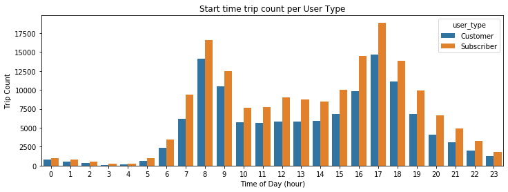

```python
plt.figure(figsize=(12,4))
sb.countplot(data = bike_data, x = 'hour_of_day', hue = 'user_type')
plt.title('Start time trip count per User Type')
plt.xlabel('Time of Day (hour)')
plt.ylabel('Trip Count');
```

### This clustered bar chart unravels a visible proportionality between them throughout the day, both following the same bimodal pattern of mid-morning and mid-to-end afternoon, with the subscribers always in bigger numbers than the casual customers.

### Jumping to another kind of feature pair, let's check the relation between the 2 types of users and the 2 types of access methods:

```
app        171545
clipper     13986
Name: rental_access_method, dtype: int64
```

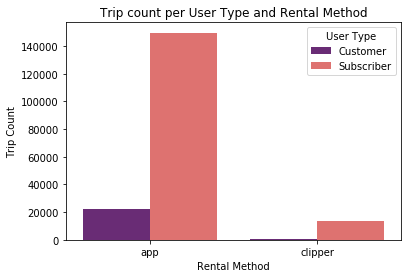

```python
sb.countplot(data = bike_data, x = 'rental_access_method', hue = 'user_type', palette='magma')
plt.title('Trip count per User Type and Rental Method')
plt.xlabel('Rental Method')
plt.ylabel('Trip Count')
plt.legend(title='User Type');
bike_data.rental_access_method.value_counts()
```

### As described by the plot and value counts table, the app method is the preferred choice, however there's still a significant amount of clipper method subscribers.

### Now, let's check the trip duration of both user types:

```
count    295159.000000
mean         11.759885
std          10.226313
min           1.000000
25%           6.000000
50%           9.000000
75%          15.000000
max         120.000000
Name: duration_min, dtype: float64
```

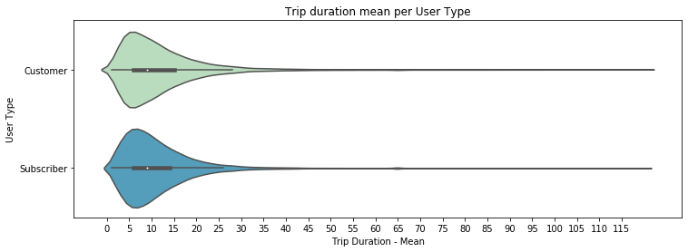

```python
plt.figure(figsize=(12,4))
sb.violinplot(data = bike_data, y = 'user_type', x = 'duration_min', palette='GnBu')
x_ticks = np.arange(0, 120, 5)
plt.xticks(x_ticks)
plt.title('Trip duration mean per User Type')
plt.xlabel('Trip Duration - Mean')
plt.ylabel('User Type');
bike_data.duration_min.describe()
```

### Through the plot and the descriptive results, it is clear that both user types have very similar trip duration patterns, with the biggest concentration happening at around 5 to 7 minutes and the mean being around 12 minutes. It is worth mentioning the presence of outliers that may mislead the mean, seeing that the 3rd quartile value is 15, but the maximum extends as further as 120. Nevertheless, having that the median is 9 minutes (2nd quartile), the mean is not so distant from a plausible representation.

### Continuing our exploration, let's discover which stations are used the most:

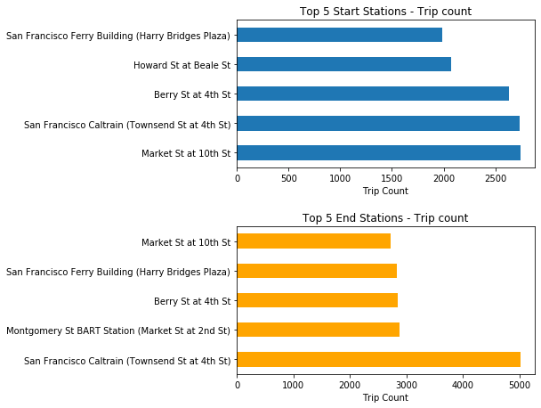

```python
### Plotting the 5 most used start stations
plt.subplot(2, 1, 1)
top_5_start = bike_data.start_station_name.value_counts()[:5]
top_5_start.plot(kind='barh')
plt.title('Top 5 Start Stations - Trip count')
plt.xlabel('Trip Count')

plt.xticks()

### Plotting the 5 most used end stations
plt.subplot(2, 1, 2)
plt.subplots_adjust(bottom = -0.5, hspace = 0.4)
top_5_end = bike_data.end_station_name.value_counts()[:5]
top_5_end.plot(kind='barh', color='orange')
plt.title('Top 5 End Stations - Trip count')
plt.xticks()
plt.xlabel('Trip Count');
```

### Interesting...with the exception of Howard St at Beale St station, all the other top 5 most used start stations repeat themselves in these results, with the addition of the Montgomery St BART Station. It is also notable the significant predominancy of the San Francisco Caltrain station trip count

```python
### There is a significant trip count among the top 5 most used stations. Let's see their proportion compared to all trips
print('% of trips starting on the top 5 most used start stations: {}'
      .format((bike_data.start_station_name.value_counts()[:5].sum()/bike_data.shape[0]*100)))
print('% of trips starting on the top 5 most used end stations: {}'
      .format((bike_data.end_station_name.value_counts()[:5].sum()/bike_data.shape[0]*100)))
```

```
% of trips starting on the top 5 most used start stations: 4.121507390931668
% of trips starting on the top 5 most used end stations: 5.518381618043156
```

### Approximately 4% of all trips start from the top 5 most used bike stations, all with quite similar trip counts. About the end stations, the top 5 represent approximately 5,5%

## Multivariable Exploration

### To start, let's plot a pair grid to spot any patterns through a macro perspective:

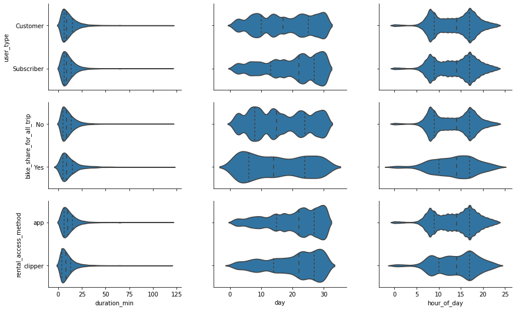

```python
g = sb.PairGrid(data = bike_data, x_vars = ['duration_min', 'day', 'hour_of_day'],
                y_vars = ['user_type','bike_share_for_all_trip', 'rental_access_method'])
plt.subplots_adjust(left=-0.5)
g.map(sb.violinplot, inner = 'quartile');
```

### In this pairplot is displayed the relations between the categorical and numerical values, with some already investigated in the bivariate exploration. These were the new revealed bivariate relations:

### - Bike Share For All trips with day of trip shows a more stable consistency between members of the program

### - User type with day of trip shows an use increase by the subscribers along the month

### - Rental access method with day of trip also displays an use increase by both app and clipper users during the month

### Furthering down our analysis, we can deepen our understanting about the data by taking more variables into consideration.

### Let's take a closer look at the Bike Share For All variable, taking into consideration the subscribers increase during the month:

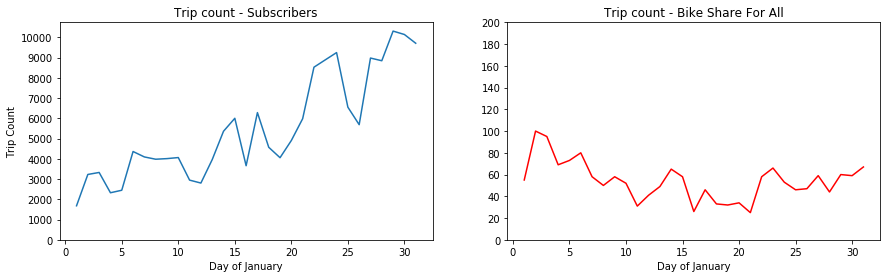

```python
subs_by_day = bike_data.query('user_type == "Subscriber"').groupby('day').day.count()
bike_for_all_by_day = bike_data.query('bike_share_for_all_trip == "Yes"').groupby('day').day.count()

plt.subplot(1, 2, 1)
plt.plot(subs_by_day)
plt.xlabel('Day of January')
plt.ylabel('Trip Count')
y_ticks_1 = np.arange(0,10001,1000)
plt.yticks(y_ticks_1)
plt.title('Trip count - Subscribers')

plt.subplot(1, 2, 2)
plt.subplots_adjust(left=-1)
plt.plot(bike_for_all_by_day, color='r')
plt.xlabel('Day of January')
y_ticks_2 = np.arange(0,201,20)
plt.yticks(y_ticks_2)
plt.title('Trip count - Bike Share For All');
```

### The subscribers growth tendency doesn't seem to push the Bike Share For All trip counts. In fact, the Bike Share For All peak in the first days was the period of the smallest subscriber counts, which later on reached frequencies around 10000 in the last days, 5 times more than the beginning of the month

### Taking into consideration the kind of user, the day and duration of trip, let's dive deeper:

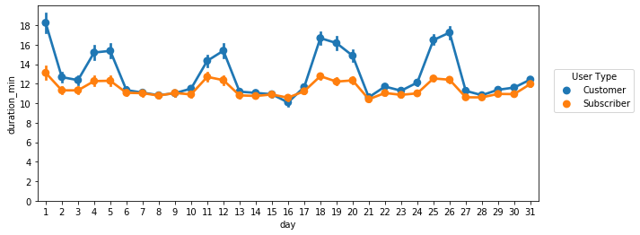

```python
plt.figure(figsize=[10,4]);
sb.pointplot(data = bike_data, x = 'day', y = 'duration_min', hue = 'user_type')
plt.legend(bbox_to_anchor=[1.2,0.7], title='User Type')
plt.ylim(0,20)
plt.yticks(np.arange(0,20,2));
```

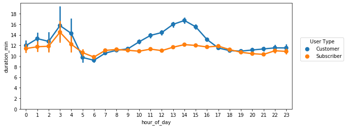

```python
plt.figure(figsize=[10,4]);
sb.pointplot(data = bike_data, x = 'hour_of_day', y = 'duration_min', hue = 'user_type')
plt.legend(bbox_to_anchor=[1.2,0.7], title='User Type')
plt.ylim(0,20)
plt.yticks(np.arange(0,20,2));
```

## Conclusions

After passing through the univariable, bivariable and multivariable analyses, we are now able to infer certain characteristics and tendencies about the features, alongside with the Bay Wheels evolution through the month of January: